# 291024test

## Часть 2

Скачайте набор данных из открытого источника. Проведите визуальный анализ выбранных данных, используя как можно больше методов, рассмотренных на втором занятии.

Диетический датасет. 1. ID 2. Возраст 3. Пол 4. Исходный вес участника (в фунтах) 5. BMR - количество энергии (в калориях) для нормальной жизнедеятельности человека в течение дня. 6. Дневное потребление калорий. 7. Дефицит или профицит дневных калорий 8. Изменение веса (в фунтах). 9. Длительность наблюдений 10. Уровень физической активности 11. Качество сна 12. Уровень стресса 13. Итоговый вес (в фунтах) About this file

Add Suggestion 1. Participant ID: Unique identifier for each participant in the study.

2. Age: The age of the participant (in years), which can influence metabolism and weight change.
3. Gender: Gender of the participant (M/F), as physiological differences may affect weight management.
4. Current Weight (lbs): The participant’s weight at the beginning of the study, serving as a baseline for weight change.
5. BMR (Calories): Basal Metabolic Rate, calculated using the Mifflin-St Jeor equation, representing the number of calories burned at rest.
6. Daily Calories Consumed: Total caloric intake per day, including variability to reflect real-world eating habits.
7. Daily Caloric Surplus/Deficit: The difference between calories consumed and BMR, indicating whether the participant is in a caloric surplus or deficit.
8. Weight Change (lbs): The estimated change in weight over a specified duration, based on caloric surplus/deficit.
9. Duration (weeks): The time period over which weight change is measured, ranging from 1 to 12 weeks.
10. Physical Activity Level: Self-reported level of physical activity, categorized as Sedentary, Lightly Active, Moderately Active, or Very Active.
11. Macronutrient Breakdown: Composition of the participant’s diet, expressed as percentages of carbohydrates, proteins, and fats.
12. Sleep Quality: Self-reported quality of sleep, categorized as Poor, Fair, Good, or Excellent, which can affect weight management.
13. Stress Level: A numerical score (1-10) indicating the participant’s perceived stress level, as stress can influence eating behaviors and weight.

```r
library(tidyverse)
```

```r
library(ggplot2)
library(patchwork)
library(GGally)
df<-read.csv("weight_change_dataset.csv")
df
```

[output not shown]

[output cut: 389 more lines]

```r
names(df)
```

```
##  [1] "Participant.ID"                "Age"
##  [3] "Gender"                        "Current.Weight..lbs."
##  [5] "BMR..Calories."                "Daily.Calories.Consumed"
##  [7] "Daily.Caloric.Surplus.Deficit" "Weight.Change..lbs."
##  [9] "Duration..weeks."              "Physical.Activity.Level"
## [11] "Sleep.Quality"                 "Stress.Level"
## [13] "Final.Weight..lbs."
```

Можно делать отдельный анализ каждого количественного признака, например, Age. * Normal Probability Plot (для проверки на нормальность) * Boxplot с каждым качественным признаком, а также с учётом пола (Gender) * Гистограммы со средними значениями и доверительным интервалом Аналогично можно применить и для остальных признаков

Age

```r
ageplot<-ggplot(df)+aes(y=Age)
```

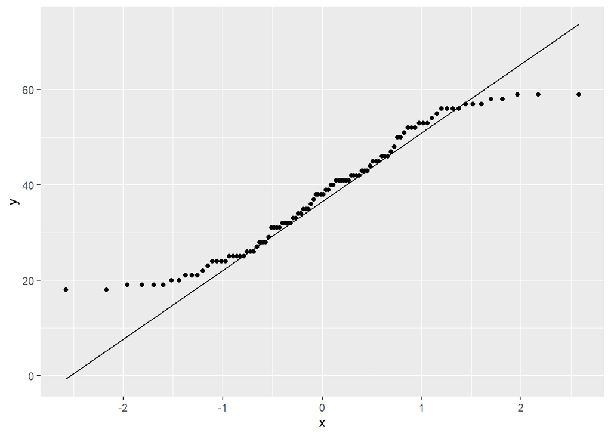

```r
ggplot(df)+aes(sample=Age)+stat_qq()+stat_qq_line()
```

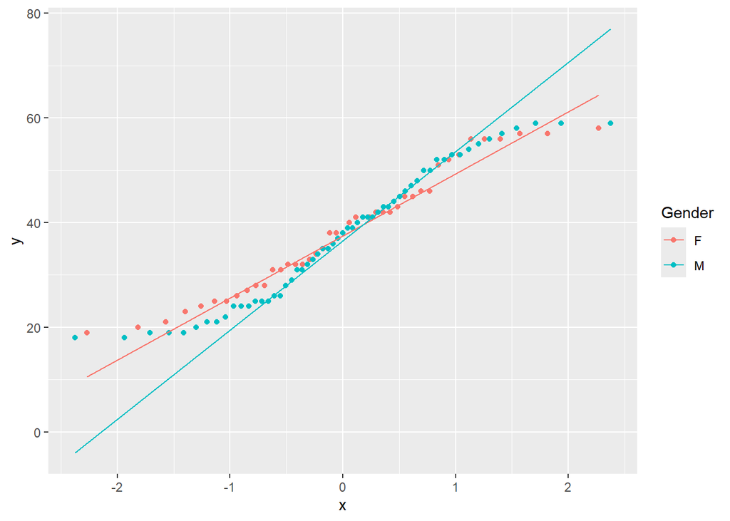

```r
ggplot(df)+aes(sample=Age, color=Gender)+stat_qq()+stat_qq_line()
```

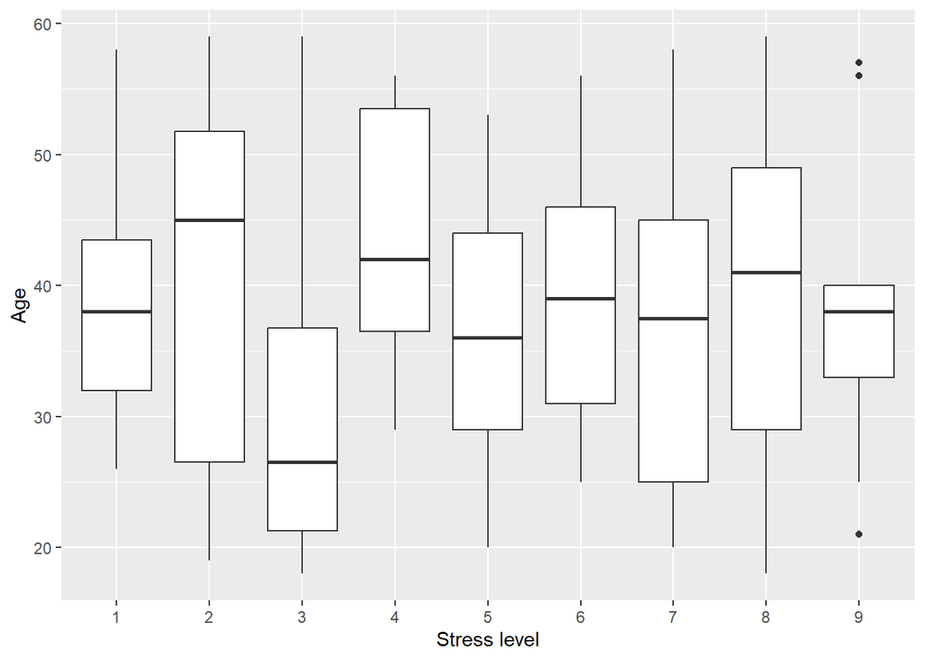

```r
ageplot+aes(x=as.factor(Stress.Level))+geom_boxplot()+labs(x="Stress level")
```

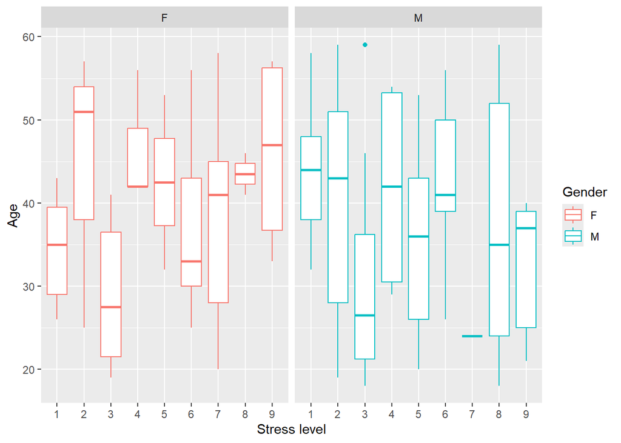

```r
ageplot+aes(x=as.factor(Stress.Level), color = Gender)+geom_boxplot()+labs(x="Stress level")+facet_wrap(~Gender)
```

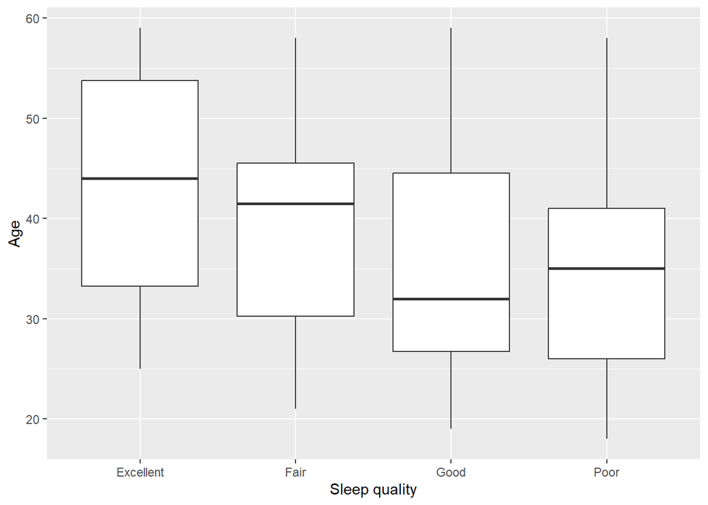

```r
ageplot+aes(x=as.factor(Sleep.Quality))+geom_boxplot()+labs(x = "Sleep quality")
```

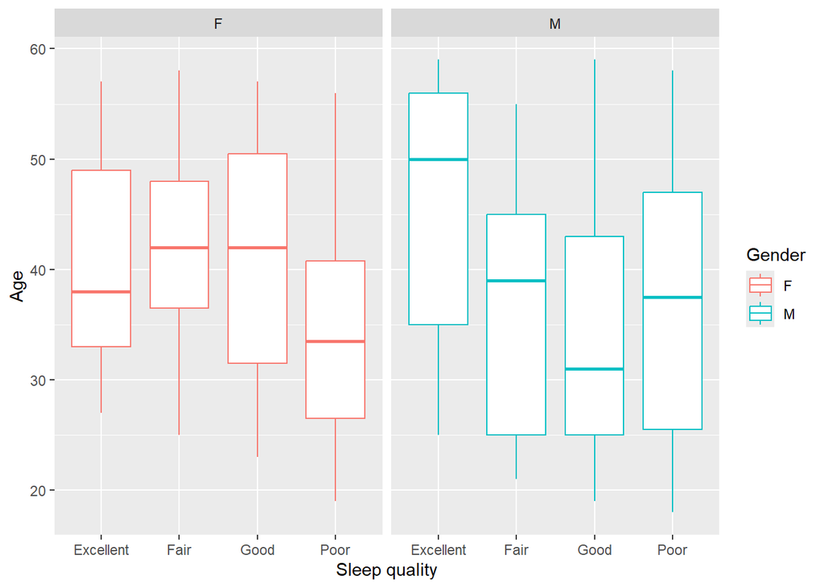

```r
ageplot+aes(x=as.factor(Sleep.Quality), color = Gender)+geom_boxplot()+labs(x = "Sleep quality")+facet_wrap(~Gender)
```

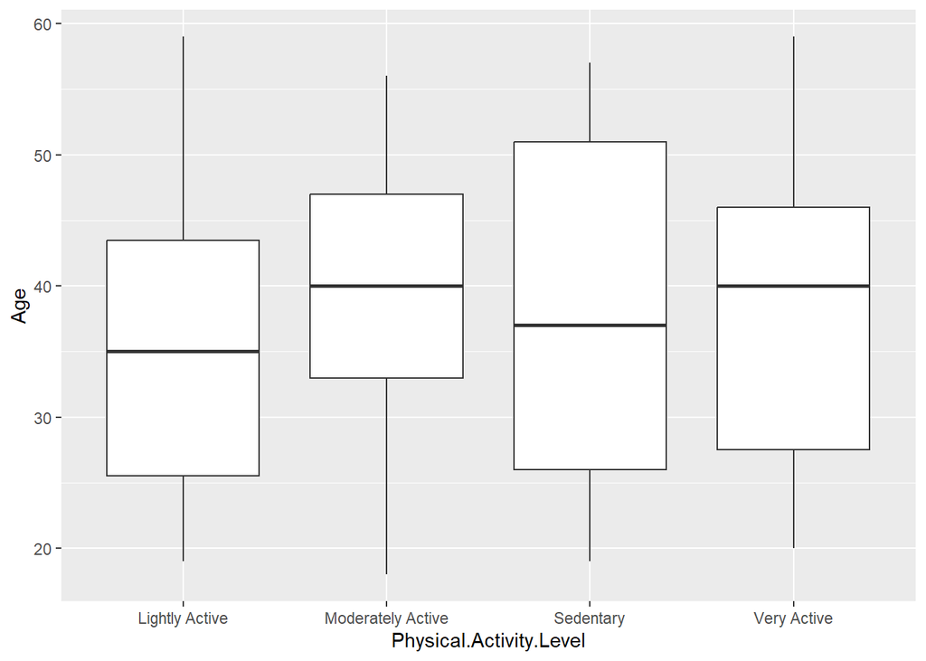

```r
ageplot+aes(x=as.factor(Physical.Activity.Level))+geom_boxplot()+labs(x = "Physical.Activity.Level")
```

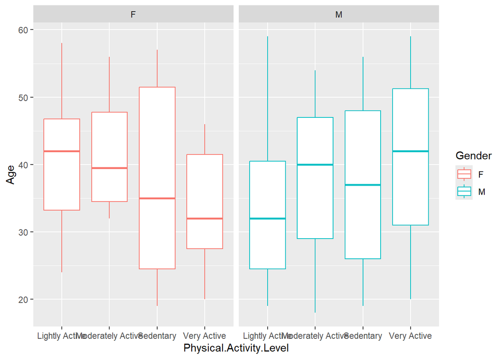

```r
ageplot+aes(x=as.factor(Physical.Activity.Level), color = Gender)+geom_boxplot()+labs(x = "Physical.Activity.Level")+facet_wrap(~Gender)
```

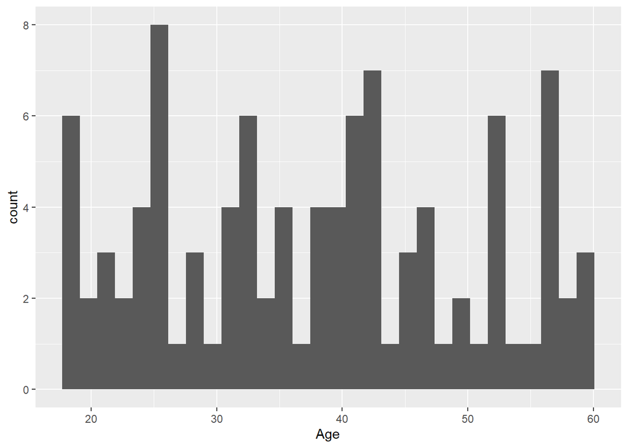

```r
ggplot(df)+aes(x=Age)+geom_histogram()
```

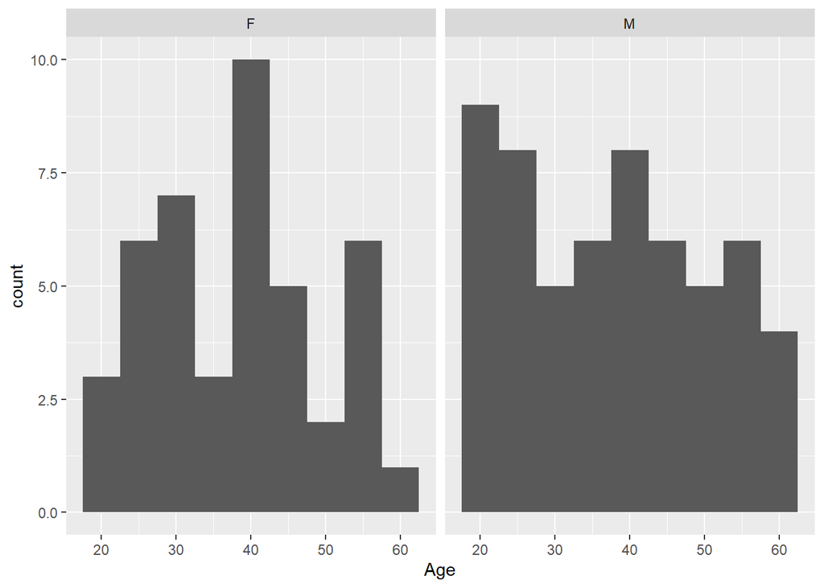

```r
ggplot(df)+aes(x=Age)+geom_histogram(binwidth = 5)+facet_wrap(~Gender)
```

На этом графике можно заметить, что мужчины потребляют больше энергии на содержание себя, чем женщины.

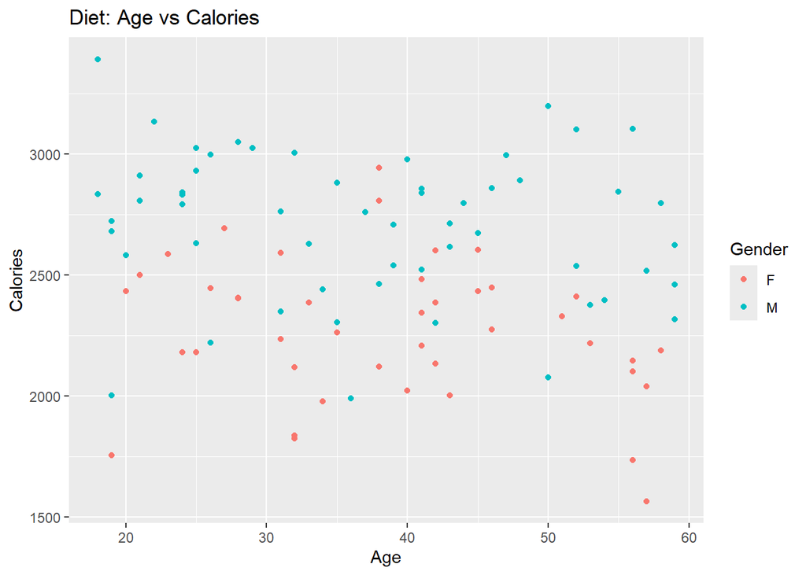

```r
age_vs_calories<-ggplot(df, aes(Age, BMR..Calories., color=Gender))+geom_point()+labs(title="Diet: Age vs Calories", x = "Age", y = "Calories")
age_vs_calories
```

В разделении (через facet_wrap())

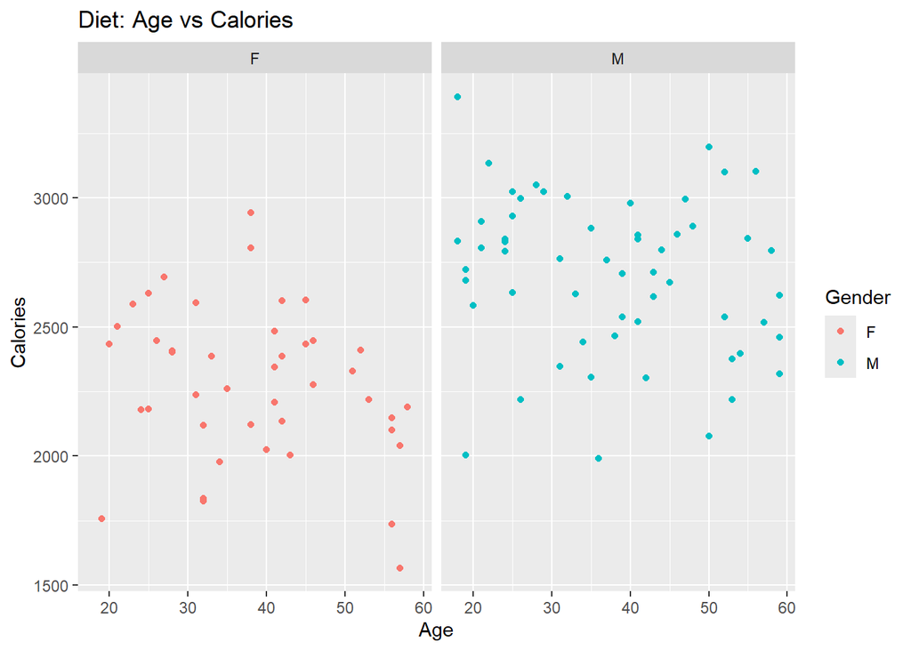

```r
ggplot(df, aes(Age, BMR..Calories., color=Gender))+geom_point()+labs(title="Diet: Age vs Calories", x = "Age", y = "Calories")+facet_wrap(~Gender)
```

Используем ggpairs, чтобы посмотреть на количественные признаки попарно. Замечаем сильную положительную корреляцию у * BMR(Calories) vs. Current_Weight * Final_Weight vs. Current_Weight * BMR(Calories) vs. Final_Weight

Можно предположить, что формула BMR зависит от веса и использует Current_Weight и Final_Weight, что имеет смысл, так как с изменением веса меняется число затрачиваемой энергии на нормальную жизнедеятельность.

```r
names(df)
```

```
##  [1] "Participant.ID"                "Age"
##  [3] "Gender"                        "Current.Weight..lbs."
##  [5] "BMR..Calories."                "Daily.Calories.Consumed"
##  [7] "Daily.Caloric.Surplus.Deficit" "Weight.Change..lbs."
##  [9] "Duration..weeks."              "Physical.Activity.Level"
## [11] "Sleep.Quality"                 "Stress.Level"
## [13] "Final.Weight..lbs."
```

```r
num_cols<-c("Age", "Current.Weight..lbs.", "BMR..Calories.", "Daily.Calories.Consumed", "Daily.Caloric.Surplus.Deficit", "Weight.Change..lbs.", "Duration..weeks.", "Final.Weight..lbs.")
qual_cols<-c("Participant.ID", "Gender", "Physical.Activity.Level", "Sleep.Quality", "Stress.Level")
# gpair<-ggpairs(df[-c(1, 3, 10, 11, 12)])
# gpair
```

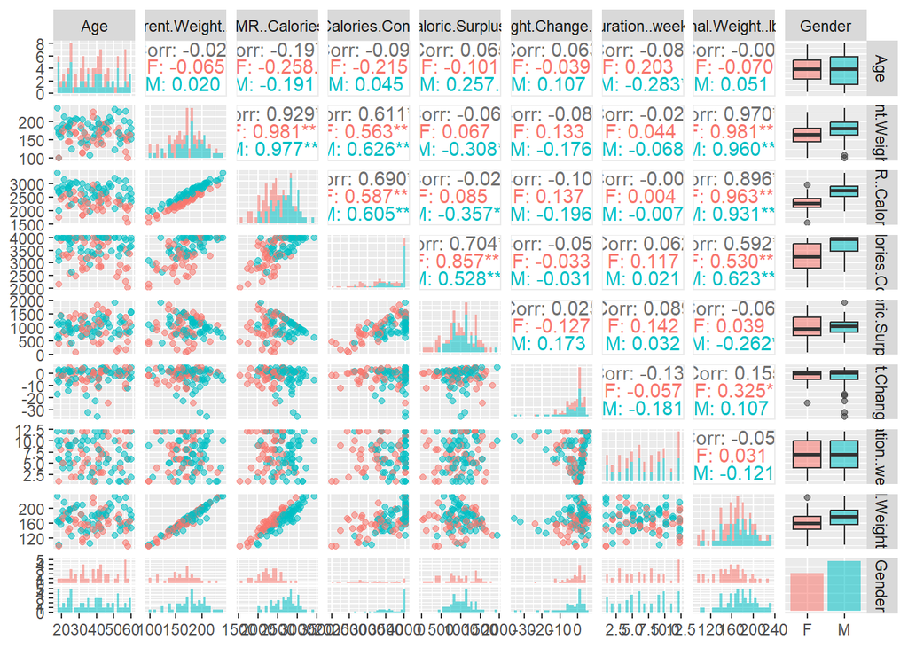

```r
ggpairs(df[c(num_cols, "Gender")], aes(color = Gender, alpha = 0.5),
        diag = list(continuous = wrap("barDiag")))
```

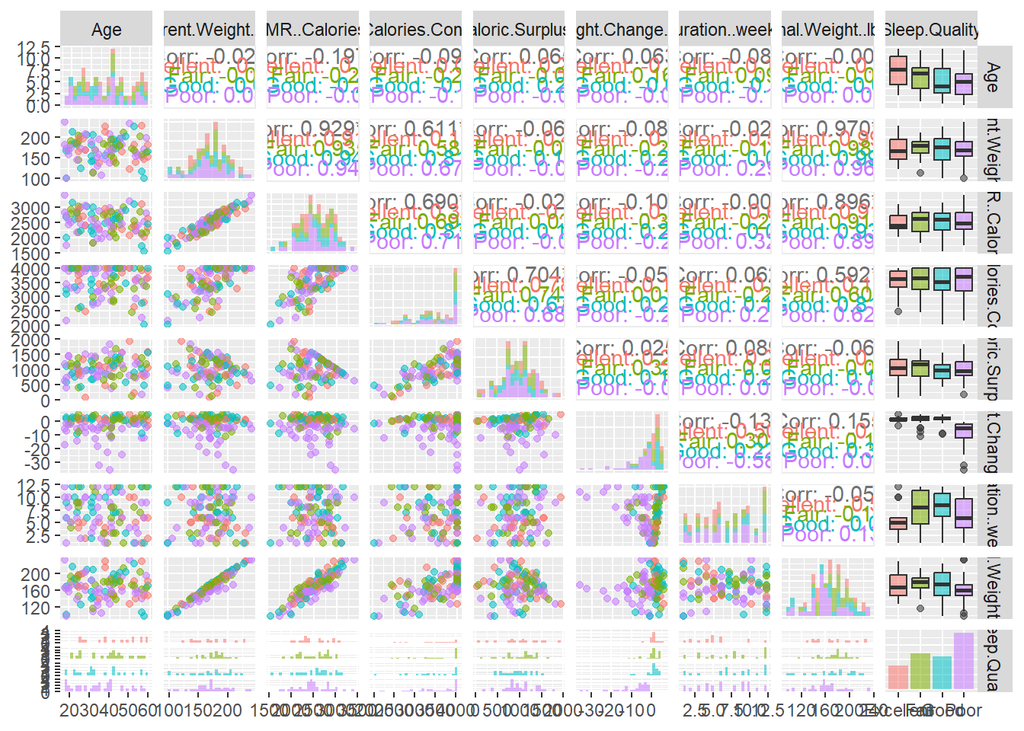

```r
ggpairs(df[c(num_cols, "Sleep.Quality")], aes(color = Sleep.Quality, alpha = 0.5),
        diag = list(continuous = wrap("barDiag", bins=20)))
```

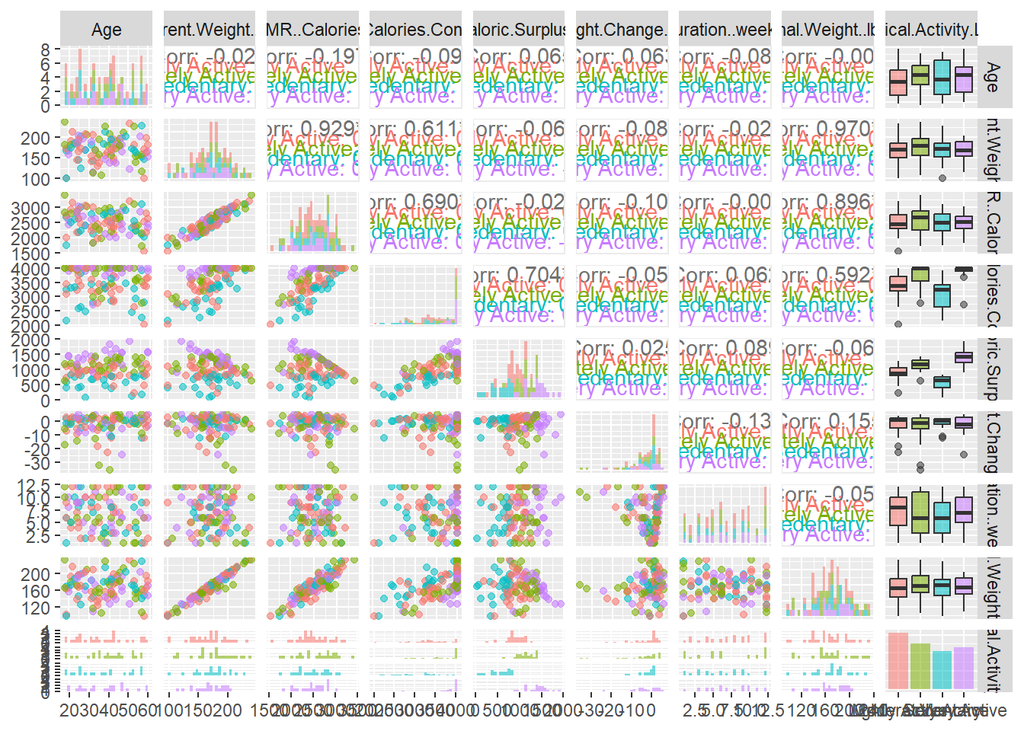

```r
ggpairs(df[c(num_cols, "Physical.Activity.Level")], aes(color = Physical.Activity.Level, alpha = 0.5),
        diag = list(continuous = wrap("barDiag")))
```

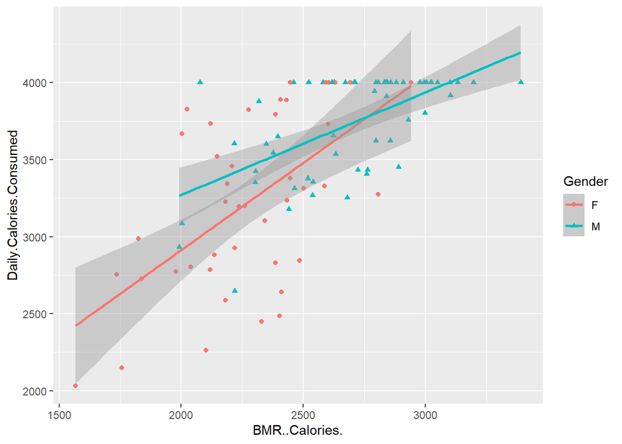

```r
gcal<-ggplot(df, aes(BMR..Calories., Daily.Calories.Consumed, color=Gender, shape=Gender)) + geom_point()
gcal + geom_smooth(method="lm", formula=y~x, se=TRUE)
```

По графику можно заметить потолок в “4000” по потребляемым калориям, что делает анализ менее точным.

Теперь посмотрим на другие графики с учётом пола и других качественных признаков При плохом качестве сна вес как у мужчин, так и у женщин чаще уменьшается.

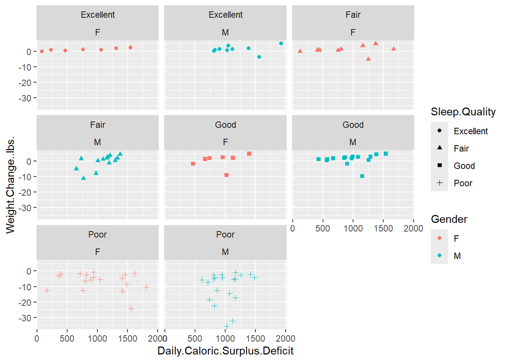

```r
gage<-ggplot(df, aes(Daily.Caloric.Surplus.Deficit, Weight.Change..lbs., color=Gender, shape=Sleep.Quality))+geom_point()+facet_wrap(~Sleep.Quality + Gender)
gage
```

Проверим соответствие данных нормальному распределению через qqplot(). Начальный вес имеет довольно схожее в плане нормальности распределение

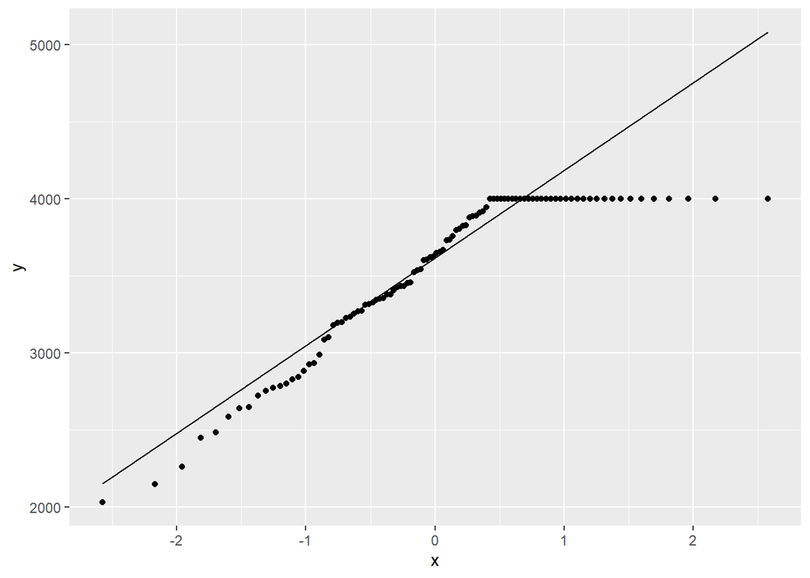

```r
dfplot<-ggplot(df)
dfplot+aes(sample=Daily.Calories.Consumed)+stat_qq()+stat_qq_line()
```

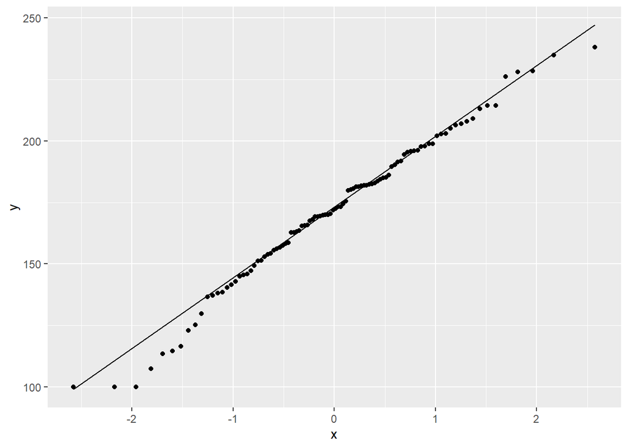

```r
dfplot+aes(sample=Current.Weight..lbs.)+stat_qq()+stat_qq_line()
```

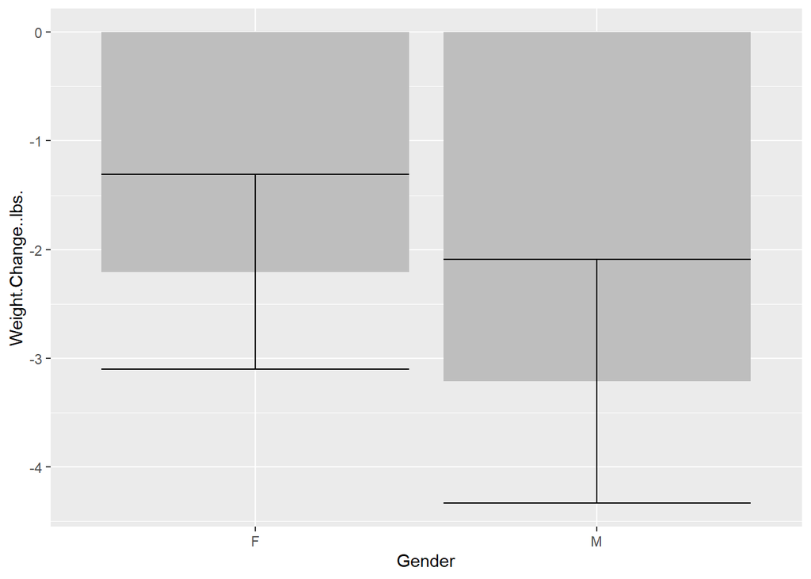

```r
ggplot(df, aes(Gender, Weight.Change..lbs.))+geom_bar(fun="mean", stat="summary", fill = "grey")+stat_summary(fun.data=mean_se, geom="errorbar")
```

Хочется сравнить дневное потребление калорий с итоговым весом и уровнем стресса. Предполагаем, что они коррелируют положительно. Посмотрим на графики

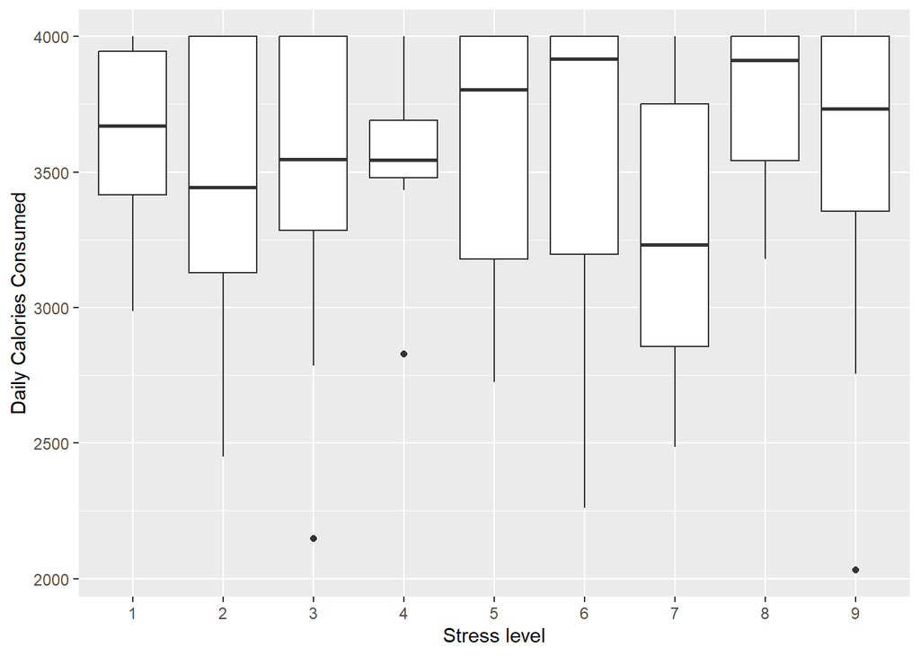

```r
g1<-ggplot(df)+aes(x=as.factor(Stress.Level), y = Daily.Calories.Consumed)+geom_boxplot()+labs(x="Stress level", y = "Daily Calories Consumed")
g2<-ggplot(df)+aes(x=as.factor(Sleep.Quality), y = Daily.Calories.Consumed)+geom_boxplot()+labs(x="Sleep quality", y = "Daily Calories Consumed")
g1
```

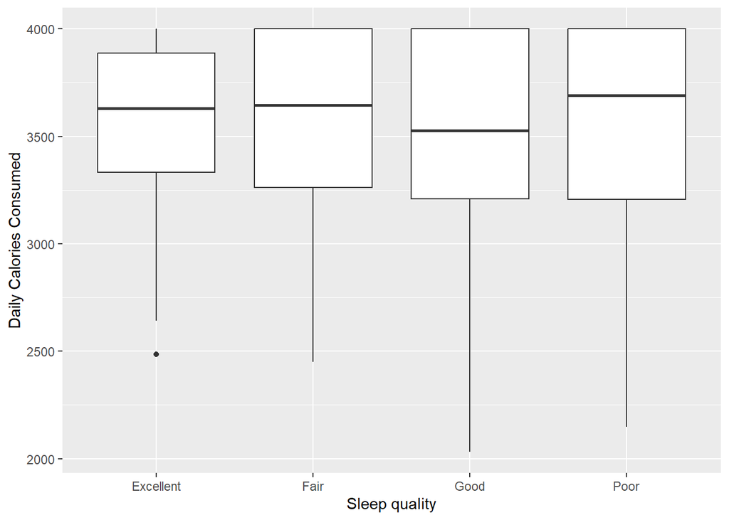

```r
g2
```

## Часть 3

Используя набор данных “housing” (содержащий статистические данные по недвижимости в Калифорнии) постройте модель прогноза цен на жилье. При построении и исследовании модели используйте как можно больше методов, рассмотренных на третьем занятии. Сделайте выводы.

```r
housing<-read.csv("housing.csv")
head(housing)
```

```
##   longitude latitude housing_median_age total_rooms total_bedrooms population
## 1   -122.23    37.88                 41         880            129        322
## 2   -122.22    37.86                 21        7099           1106       2401
## 3   -122.24    37.85                 52        1467            190        496
## 4   -122.25    37.85                 52        1274            235        558
## 5   -122.25    37.85                 52        1627            280        565
## 6   -122.25    37.85                 52         919            213        413
##   households median_income median_house_value ocean_proximity
## 1        126        8.3252             452600        NEAR BAY
## 2       1138        8.3014             358500        NEAR BAY
## 3        177        7.2574             352100        NEAR BAY
## 4        219        5.6431             341300        NEAR BAY
## 5        259        3.8462             342200        NEAR BAY
## 6        193        4.0368             269700        NEAR BAY
```

```r
summary(housing)
```

```
##    longitude         latitude     housing_median_age  total_rooms
##  Min.   :-124.3   Min.   :32.54   Min.   : 1.00      Min.   :    2
##  1st Qu.:-121.8   1st Qu.:33.93   1st Qu.:18.00      1st Qu.: 1448
##  Median :-118.5   Median :34.26   Median :29.00      Median : 2127
##  Mean   :-119.6   Mean   :35.63   Mean   :28.64      Mean   : 2636
##  3rd Qu.:-118.0   3rd Qu.:37.71   3rd Qu.:37.00      3rd Qu.: 3148
##  Max.   :-114.3   Max.   :41.95   Max.   :52.00      Max.   :39320
##
##  total_bedrooms     population      households     median_income
##  Min.   :   1.0   Min.   :    3   Min.   :   1.0   Min.   : 0.4999
##  1st Qu.: 296.0   1st Qu.:  787   1st Qu.: 280.0   1st Qu.: 2.5634
##  Median : 435.0   Median : 1166   Median : 409.0   Median : 3.5348
##  Mean   : 537.9   Mean   : 1425   Mean   : 499.5   Mean   : 3.8707
##  3rd Qu.: 647.0   3rd Qu.: 1725   3rd Qu.: 605.0   3rd Qu.: 4.7432
##  Max.   :6445.0   Max.   :35682   Max.   :6082.0   Max.   :15.0001
##  NA's   :207
##  median_house_value ocean_proximity
##  Min.   : 14999     Length:20640
##  1st Qu.:119600     Class :character
##  Median :179700     Mode  :character
##  Mean   :206856
##  3rd Qu.:264725
##  Max.   :500001
##
```

```r
nms<-names(housing)
unique(housing$ocean_proximity)
```

```
## [1] "NEAR BAY"   "<1H OCEAN"  "INLAND"     "NEAR OCEAN" "ISLAND"
```

Пустующие значения total_bedrooms можно попробовать заменить на среднее

```r
houseplot<-ggplot(housing)
```

Можно получить силуэт Калифорнии, если рассмотреть график по longitude, latitude

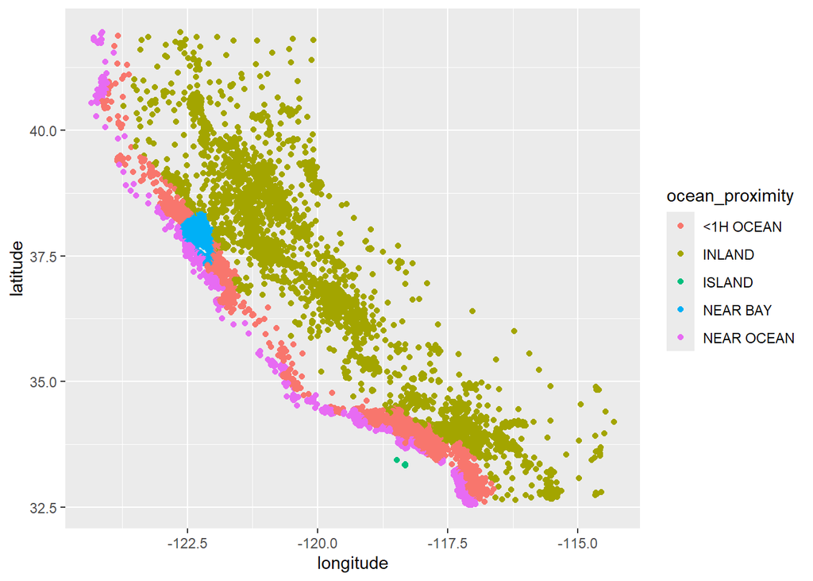

```r
houseplot+aes(longitude, latitude, color=ocean_proximity)+geom_point()
```

```r
nms
```

```
##  [1] "longitude"          "latitude"           "housing_median_age"
##  [4] "total_rooms"        "total_bedrooms"     "population"
##  [7] "households"         "median_income"      "median_house_value"
## [10] "ocean_proximity"
```

```r
library(car)
library(tidyverse)
```

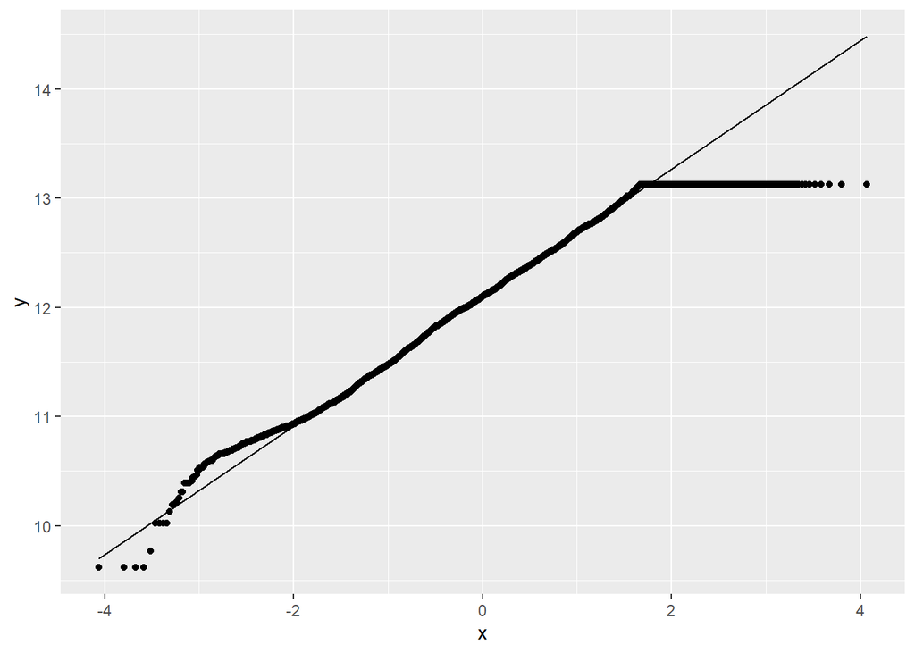

```r
houseplot+aes(sample=log(median_house_value))+stat_qq()+stat_qq_line()
```

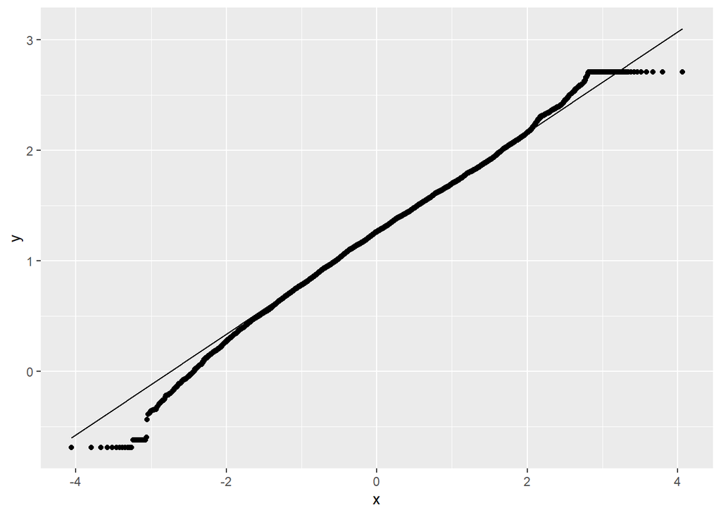

```r
houseplot+aes(sample=log(median_income))+stat_qq()+stat_qq_line()
```

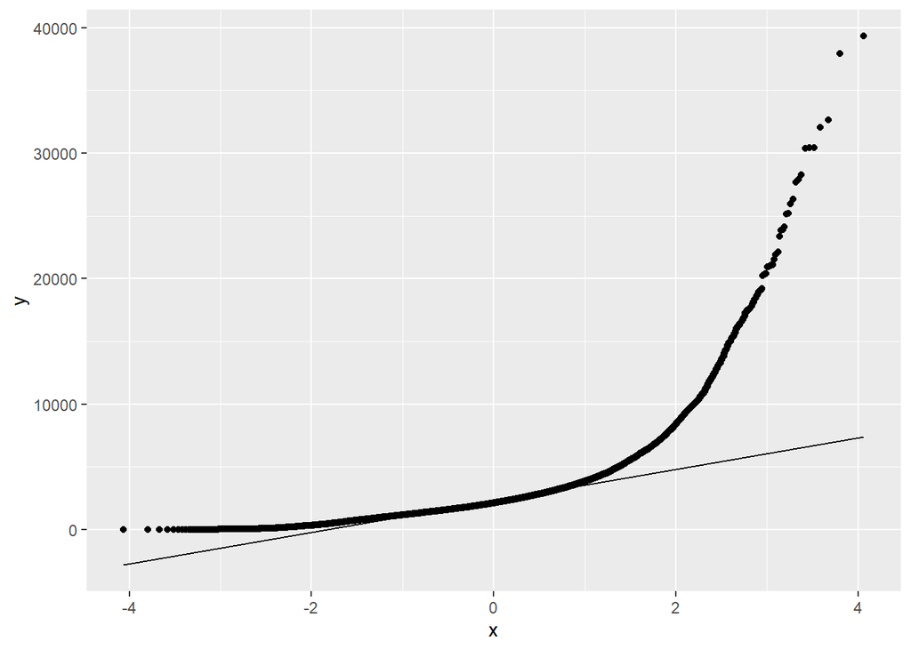

```r
houseplot+aes(sample=total_rooms)+stat_qq()+stat_qq_line()
```

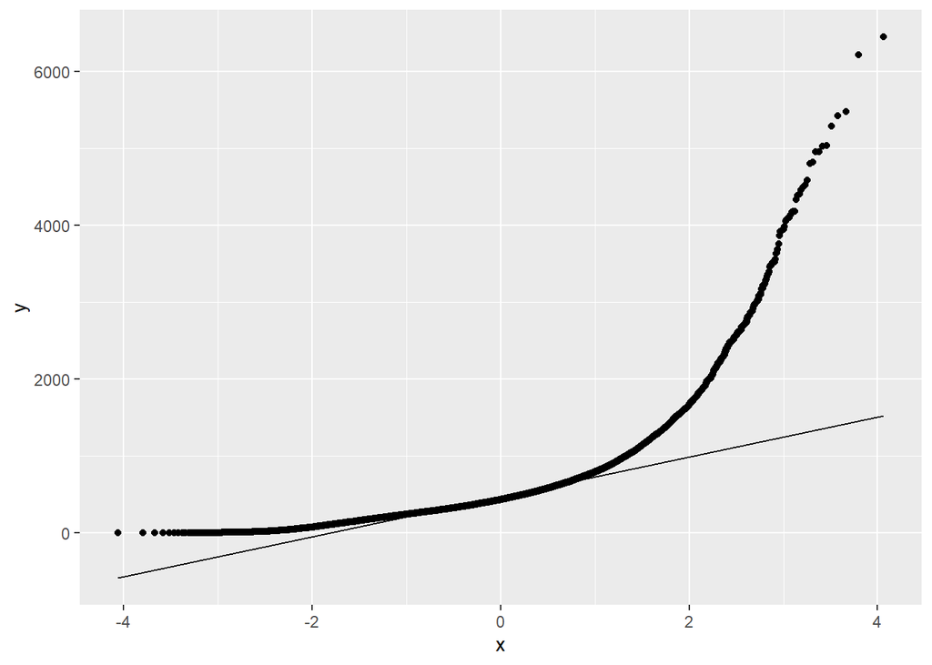

```r
houseplot+aes(sample=total_bedrooms)+stat_qq(na.rm=TRUE)+stat_qq_line()
```

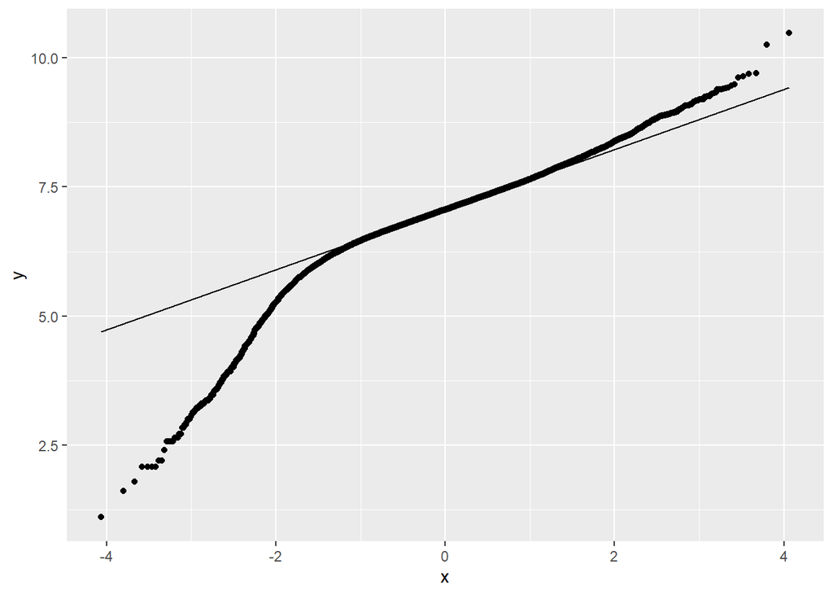

```r
houseplot+aes(sample=log(population))+stat_qq()+stat_qq_line()
```

Можно увидеть, что median_house_value и median_income имеют близкое к lognorm распределению. total_rooms и total_bedrooms зависимы, так как число комнат зависит от числа спален.

```r
total_rooms<-housing$total_rooms
total_bedrooms<-housing$total_bedrooms
m_beddoor<-lm(total_rooms~total_bedrooms)
bc<-boxCox(m_beddoor)
```

[figure not shown]

```r
lambda<-bc$x[which.max(bc$y)]
total_rooms<-total_rooms^lambda
m_n<-lm(total_rooms~total_bedrooms)
summary(m_beddoor)
```

```
##
## Call:
## lm(formula = total_rooms ~ total_bedrooms)
##
## Residuals:
##     Min      1Q  Median      3Q     Max
## -8055.3  -310.6   -10.2   296.5 11498.8
##
## Coefficients:
##                Estimate Std. Error t value Pr(>|t|)
## (Intercept)     41.3464     9.0879    4.55 5.41e-06 ***
## total_bedrooms   4.8249     0.0133  362.76  < 2e-16 ***
## ---
## Signif. codes:  0 '***' 0.001 '**' 0.01 '*' 0.05 '.' 0.1 ' ' 1
##
## Residual standard error: 801.1 on 20431 degrees of freedom
##   (207 пропущенных наблюдений удалены)
## Multiple R-squared:  0.8656, Adjusted R-squared:  0.8656
## F-statistic: 1.316e+05 on 1 and 20431 DF,  p-value: < 2.2e-16
```

```r
summary(m_n)
```

```
##
## Call:
## lm(formula = total_rooms ~ total_bedrooms)
##
## Residuals:
##     Min      1Q  Median      3Q     Max
## -439.28  -19.57   -1.20   18.83  168.10
##
## Coefficients:
##                 Estimate Std. Error t value Pr(>|t|)
## (Intercept)    7.643e+01  3.935e-01   194.2   <2e-16 ***
## total_bedrooms 1.943e-01  5.759e-04   337.4   <2e-16 ***
## ---
## Signif. codes:  0 '***' 0.001 '**' 0.01 '*' 0.05 '.' 0.1 ' ' 1
##
## Residual standard error: 34.69 on 20431 degrees of freedom
##   (207 пропущенных наблюдений удалены)
## Multiple R-squared:  0.8479, Adjusted R-squared:  0.8479
## F-statistic: 1.139e+05 on 1 and 20431 DF,  p-value: < 2.2e-16
```

Получили R-squared = 0.8656, что подразумевает сильную зависимость total_rooms от total_bedrooms.